# P8130 Assignment 1

Emil Hafeez (eh2928)

9/18/2020

Assignment 1 for Biostatistics P8130, using a dataset called Antibodies, practices data manipulation and descriptive statistics (including table, histogram, and boxplot generation). The dataset contains information on demographic variables, IgM antibodies, and self-reported smell loss for patients diagnosed with COVID-19 (via the PCR gold-standard).

Let’s load the appropriate packages first.

```r
library(arsenal)
library(dplyr)
library(ggplot2)
library(tidyverse)
library(knitr)
```

# Question 1

## Question 1, Part 1, Section a)

[output not shown]

I examine the basics of the data, to become familiar. Results are hidden for the sake of brevity.

```r
names(antibodies_df)
nrow(antibodies_df)
ncol(antibodies_df)
head(antibodies_df)
tail(antibodies_df)
anyNA(antibodies_df)
str(antibodies_df)
```

Now, we can provide descriptive statistics for all variables of interest. We can see that some variable types need manipulation, too. I suppress the code output here.

```r
summary(antibodies_df)

# Make AgeCategory, Smell, and Gender appopriate datatypes. Helps to ensure we know all unique values, too.
unique(antibodies_df$AgeCategory)
    antibodies_df <- antibodies_df %>%
        mutate(AgeCategory = factor(AgeCategory, labels = c("18-30", "31-50", "51+") ))
unique(antibodies_df$Smell)
    antibodies_df <- antibodies_df %>%
        mutate(Smell = factor(Smell, levels = c("Normal","Altered", "Unanswered/Others")))
    antibodies_df = antibodies_df %>% filter(Smell != "Unanswered/Others")
unique(antibodies_df$Gender)
    antibodies_df <- antibodies_df %>%
        mutate(Gender = factor(Gender, levels = c("Male","Female")))
```

```r
# To prepare a tidy table, let's change variable names/labels by creating a my_labels variable that will modify the tableby() command
my_labels <- list(AgeCategory = "Age Range (Years)", Antibody_IgM = "Antibody Levels(IgM)", Smell = "Smell Changes (Filtered to Binary)", Gender = "Gender (M/F)")

# Clean the output by creating a my_controls variable that will modify the tableby() command
my_controls <- tableby.control(
               total = TRUE,
               test = FALSE,
               numeric.stats = c("meansd", "medianq1q3", "range", "Nmiss2"),
               cat.stats = c("countpct", "Nmiss2"),
               stats.labels = list(
               meansd = "Mean (SD)",
               medianq1q3 = "Median (Q1, Q3)",
               range = "Min - Max",
               Nmiss2 = "Missing",
               countpct = "N (%)"))
```

```r
#Making Table 1
table_1 <- tableby( ~ AgeCategory + Antibody_IgM + Smell + Gender, data = antibodies_df, control = my_controls)
summary(table_1, title = "Table 1 Descriptive Statistics: Antibodies & Smell Data", labelTranslations = my_labels, text = TRUE)
```

```
##
## Table: Table 1 Descriptive Statistics: Antibodies & Smell Data
##
## |                                   |   Overall (N=1457)   |
## |:----------------------------------|:--------------------:|
## |Age Range (Years)                  |                      |
## |-  18-30                           |     311 (21.3%)      |
## |-  31-50                           |     787 (54.0%)      |
## |-  51+                             |     359 (24.6%)      |
## |-  Missing                         |          0           |
## |Antibody Levels(IgM)               |                      |
## |-  Mean (SD)                       |    0.124 (0.112)     |
## |-  Median (Q1, Q3)                 | 0.090 (0.069, 0.130) |
## |-  Min - Max                       |    0.048 - 1.048     |
## |-  Missing                         |         1198         |
## |Smell Changes (Filtered to Binary) |                      |
## |-  Normal                          |     410 (28.1%)      |
## |-  Altered                         |     1047 (71.9%)     |
## |-  Unanswered/Others               |       0 (0.0%)       |
## |-  Missing                         |          0           |
## |Gender (M/F)                       |                      |
## |-  Male                            |     498 (34.2%)      |
## |-  Female                          |     959 (65.8%)      |
## |-  Missing                         |          0           |
```

### Question 1, Part 1, Section b)

```r
#1.0475
min(antibodies_df$Antibody_IgM)
```

```
## [1] NA
```

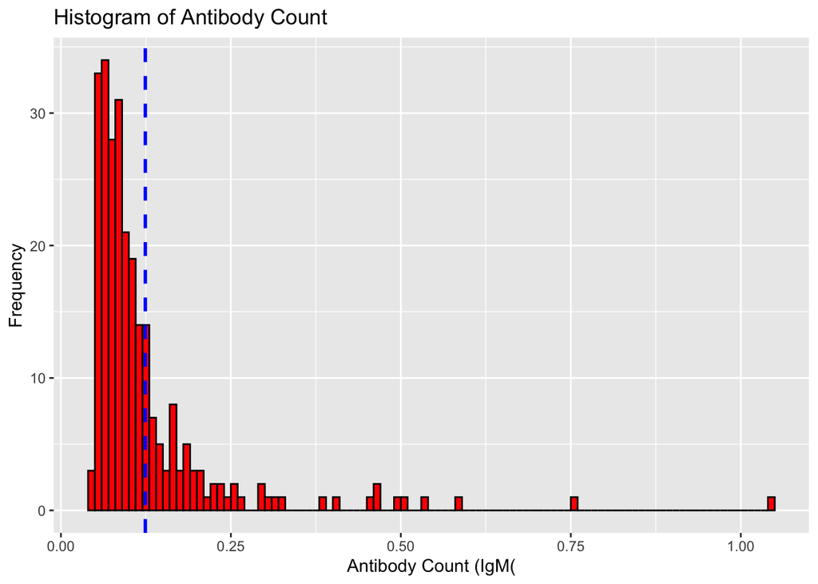

```r
#0.0480

ggplot(antibodies_df, aes(Antibody_IgM)) +
  geom_histogram(col = "black", fill = "red", breaks = seq(0.0400,1.05,.01)) +
  geom_vline(aes(xintercept = mean(Antibody_IgM, na.rm = TRUE)), color = "blue", linetype = "dashed", size = 1) +
  labs(title = "Histogram of Antibody Count") +
  labs(x = "Antibody Count (IgM(", y = "Frequency")
```

## Question 1, Part 2, Section a)

Let’s display the descriptive statistics for all variables, this time stratified by Smell category

```r
#Similar structure to the above code, though note that Smell appears as a stratifier before the '~'
table_2 <- tableby( Smell ~ AgeCategory + Antibody_IgM + Smell + Gender, data = antibodies_df, control = my_controls)
summary(table_2, title = "Descriptive Statistics: Antibodies & Smell Data", labelTranslations = my_labels, text = TRUE)
```

```
##
## Table: Descriptive Statistics: Antibodies & Smell Data
##
## |                     |    Normal (N=410)    |   Altered (N=1047)   |    Total (N=1457)    |
## |:--------------------|:--------------------:|:--------------------:|:--------------------:|
## |Age Range (Years)    |                      |                      |                      |
## |-  18-30             |      66 (16.1%)      |     245 (23.4%)      |     311 (21.3%)      |
## |-  31-50             |     215 (52.4%)      |     572 (54.6%)      |     787 (54.0%)      |
## |-  51+               |     129 (31.5%)      |     230 (22.0%)      |     359 (24.6%)      |
## |-  Missing           |          0           |          0           |          0           |
## |Antibody Levels(IgM) |                      |                      |                      |
## |-  Mean (SD)         |    0.110 (0.092)     |    0.130 (0.119)     |    0.124 (0.112)     |
## |-  Median (Q1, Q3)   | 0.081 (0.065, 0.107) | 0.097 (0.072, 0.137) | 0.090 (0.069, 0.130) |
## |-  Min - Max         |    0.049 - 0.589     |    0.048 - 1.048     |    0.048 - 1.048     |
## |-  Missing           |         329          |         869          |         1198         |
## |Gender (M/F)         |                      |                      |                      |
## |-  Male              |     173 (42.2%)      |     325 (31.0%)      |     498 (34.2%)      |
## |-  Female            |     237 (57.8%)      |     722 (69.0%)      |     959 (65.8%)      |
## |-  Missing           |          0           |          0           |          0           |
```

## Question 1, Part 2, Section b)

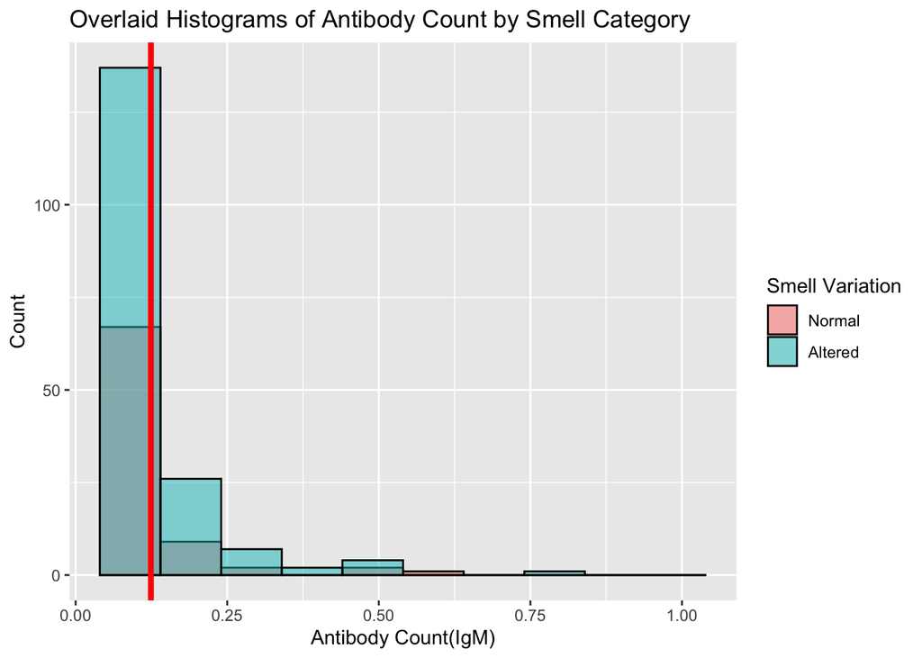

```r
# Generate overlaid histograms and boxplots with a variety of formatting edits, including aesthetic and labeling.
# Histogram
ggplot(antibodies_df, aes(x = Antibody_IgM, fill = factor(Smell))) +
  geom_histogram(binwidth = .5, alpha = .5, position = "identity", col = "black", breaks = seq(0.0400,1.05,.1)) +
  geom_vline(aes(xintercept = mean(Antibody_IgM, na.rm = TRUE)), color = "red", size = 1.5) +
  labs(title = "Overlaid Histograms of Antibody Count by Smell Category") +
  labs(x = "Antibody Count(IgM)", y = "Count") +
  scale_fill_discrete(name = "Smell Variation", labels = c("Normal", "Altered", "Other"))
```

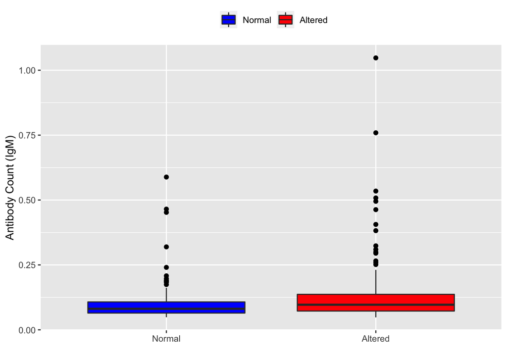

```r
# Boxplot
ggplot(antibodies_df, aes(x = Smell, y = Antibody_IgM, fill = Smell)) +
  geom_boxplot(outlier.colour = "black", outlier.shape = 16,
               outlier.size = 2, notch = FALSE) +
  scale_fill_manual(values = c("blue", "red", "yellow"),
                    labels = expression("Normal", "Altered", "Other")) +
  xlab("") +
  ylab("Antibody Count (IgM)") +
  theme(legend.position = "top", legend.title = element_blank())
```

Utilizing these overlaid histograms and boxplots, we can see that both the Smell categories of Normal and Altered appear to show a positive (right) skew in their distributions of Antibody Count (IgM), with long tails extending to the right (or up, in the boxplots) and a substantial number of outliers. Most data appear to fall in a similar range, with substantial overlap between the box plots; however, it does appear that the Normal category has lower variation, including a smaller interquartile range than the Altered group, as well as more condensed outliers.

# Question 2

## Question 2, Summary and Three Focus Points

[output not shown]

1. Fox, Maggie. Coronavirus can spread on airline flights, two studies show. CNN, Cable News Network, 18 Sept. 2020 [cited 19 September 2020]. www.cnn.com/2020/09/18/health/coronavirus-airline-transmission-studies/index.html.
2. Khanh NC, Thai PQ, Quach H-L, Thi NA-H, Dinh PC, Duong TN, et al. Transmission of severe acute respiratory syndrome coronavirus 2 during long flight. Emerg Infect Dis. 2020 Nov [cited 19 September 2020]. https://doi.org/10.3201/eid2611.203299